# Spotify Dataset Exploration

## Data Gathering

#### Spotify allows its users to be able to download his/her music play history and the app usage history over the past year (1 year only), in this case July 2019 - July 2020.

#### This data is used to perform the aforementioned analysis. This data can be downloaded by placing a request to Spotify, they will send a link to download the data in the form of zip files.

```python
!pip3 install pandas
!pip3 install spotipy
!pip3 install wordcloud
!pip3 install seaborn
!pip3 install matplotlib
```

```python
import pandas as pd
import numpy as np
import spotipy
import os
from spotipy.oauth2 import SpotifyClientCredentials
import lyricsgenius as genius
from datetime import datetime
import re
from csv import DictWriter
import matplotlib.pyplot as plt
import math
import seaborn as sns
sns.set_style("darkgrid")
```

#### In order to get more information regarding the songs, we need to create an app in the developers portal of Spotify. This will enable us to retrieve features of each song, along with the song URI, which is a direct link to the song on Spotify.

```python
# The client id and client secret are stored as environment variables, so as to avoid writing in clear text here.
# These are required to authenticate out application with Spotify, in order to use their API.

client_id = os.environ.get('SPOTIPY_CLIENT_ID')
client_secret = os.environ.get('SPOTIPY_CLIENT_SECRET')
redirect_URI = 'http://localhost:7777/callback'
auth_manager = SpotifyClientCredentials(client_id=client_id, client_secret=client_secret)
sp = spotipy.Spotify(auth_manager=auth_manager)
sp.trace = False
```

#### Since the song streaming history is spread across multiple JSON files, we read and combine them into a single dataframe.

```python
part0 = pd.read_json("StreamingHistory0.json")
part1 = pd.read_json("StreamingHistory1.json")
spotify_data = pd.concat([part0, part1], sort=False)
spotify_data.endTime = pd.to_datetime(spotify_data.endTime, format="%Y-%m-%d %H:%M")
spotify_data.to_csv('spotify_data.csv', index=False)
```

```python
len(spotify_data)
```

```
17627
```

#### The streaming history consists of all the songs I have heard over the course of the past 365 days, this means that I would have heard a song more than one times. So, to get a list of unique songs, I create a separate dataframe.

```python
unique_tracks = spotify_data.drop_duplicates(subset=['artistName', 'trackName'], keep='last')
unique_tracks.head()
```

|  | endTime | artistName | trackName | msPlayed |
| --- | --- | --- | --- | --- |
| 0 | 2019-07-19 01:37:00 | Ludwig van Beethoven | Beethoven: Symphony No. 7 in A Major, Op. 92: ... | 384724 |
| 1 | 2019-07-19 01:51:00 | Gustav Mahler | Symphony No. 9 in D Major: I. Andante comodo | 810540 |
| 2 | 2019-07-19 01:55:00 | Kyson | You | 236719 |
| 4 | 2019-07-19 02:02:00 | Fossil Collective | Disarm | 96832 |
| 6 | 2019-07-19 03:15:00 | César Franck | Violin Sonata in A Major, FWV 8: IV. Allegrett... | 39410 |

```python
# A function to retrieve the URI of each song in the dataframe based on the artist name and track name.

def get_song_URI(artist, title):
    query = title + ' ' + artist
    res = sp.search(query)
    for i in res['tracks']['items']:
        if (i['artists'][0]['name'] == artist) and (i['name'] == title):
            return i['uri']
        else:
            try:
                return res['tracks']['items'][0]['uri']
            except:
                # No results for artist and title
                return "Cannot Find URI"
```

Here, we use pandas apply() function to add values row by row to our URI column. So, we use the artist name and track name, send it to the above function and store the appropriate value for the URI.

```python
unique_tracks['URI'] = unique_tracks.apply(lambda row: get_song_URI(
            artist=row['artistName'], title=row['trackName']
        ), axis=1
    )
```

Some songs do not have a URI, this could be due to 2 reasons

1. It is not a song, probably a podcast.
2. It has been deleted or taken down by Spotify and does not exist anymore.

Hence, they must be removed because we can only get features of the song (danceability, energy etc.. ) if the song has a valid URI associated to it.

This removal is done in 2 steps:

1. Fetch all the rows which don't have a URI, this will include podcasts also.
2. Append them to the dataframe twice and remove the duplicates and save the resultant dataframe into a csv file.

```python
no_uri = unique_tracks[unique_tracks.URI.isnull()]
```

```python
podcasts = [
    'Your Daily Drive', 'The Daily Poem', 'Hardcore Philosophy', 'The Secret History of the Future',
    'Stuff You Should Know', 'Dgit Daily Podcast', 'Girl In Space', 'The NoSleep Podcast',
    "Dan Carlin's Hardcore History", '99% Invisible', 'TED Radio Hour', 'IRL - Online Life Is Real Life',
    'The Pitch', 'The Stack Overflow Podcast', 'Invisibilia', 'Guided Sleep Meditations',
    'Guided Sleep Meditation & Sleep Hypnosis from Sleep Cove', 'The Vergecast', 'Arts & Ideas',
    'Wind of Change ', 'Wake Up / Wind Down (US)', 'Kind World', 'Daily Quote',
    'Harry Potter At Home: Readings – Harry Potter and the Philosopher’s / Sorcerer’s Stone',
    'Now For Tomorrow with Deepak Chopra', 'Optimal Living Daily: Personal Development & Minimalism',
    'The Daily Refresh', 'Snacks Daily', 'Hidden Brain', 'Darknet Diaries', 'Spotify', 'The Truth',
    'DIY Money | Personal Finance, Budgeting, Debt, Savings, Investing', 'Tech Tonics', 'The Daily Shine',
    'Overheard at National Geographic', 'Exponential View with Azeem Azhar', 'The Daily Refresh',
    'CYBER', 'Radio Headspace', 'The Other Stories | Sci-Fi, Horror, Thriller, WTF Stories', 'Faerie',
    'The 85 South Show with Karlous Miller, DC Young Fly and Clayton English', 'Sleep With Me',
    "Sean Carroll's Mindscape: Science", 'Son of a Hitman', 'Kind World', 'Audio Plays by MACHAAN',
    'Reply All', 'Reset', 'Hannibal Buress: Handsome Rambler', 'Malicious Life', 'Every Little Thing',
    "Sean Carroll's Mindscape: Science, Society, Philosophy, Culture, Arts, and Ideas", 'the bioinformatics chat',
    'Freakonomics Radio', 'The Indianaut Podcast', 'My Favorite Murder with Karen Kilgariff and Georgia Hardstark'
]
```

```python
# Once we've defined the list of podcasts to be removed, the other rows which don't have URIs are obviously songs.

podcasts_df = no_uri.query("artistName in @podcasts")
no_uri_songs_df = no_uri.query("artistName not in @podcasts")
```

Here I am also saving a copy of only the songs from the original data gathered from Spotify, after removing the Podcasts.

Podcasts are removed by appending a the podcast dataframe to the original dataframe and deleting the duplicates without keeping a copy

```python
spotify_data_songs = pd.concat([spotify_data, podcasts_df, podcasts_df]).drop_duplicates(keep=False)
spotify_data_songs.to_csv('spotify_data_songs.csv', index=False)
```

I also want to delete the podcasts and no_uri songs from the list of unique_tracks, this is done in the following step.

The idea is to have one dataframe which has all the songs, including repetitions ( songs I listened to again and again ) and another dataframe which has the details of all the songs ( audio features - danceability, energy, tempo ) here, I do not want any repetitions.

```python
songs_df = pd.concat(
        [unique_tracks, no_uri_songs_df, no_uri_songs_df, podcasts_df, podcasts_df]
    ).drop_duplicates(keep=False)
songs_df.shape
```

[output not shown]

#### Next step is to fetch the song features using the songs which have a URI associated to them. We use the _audio*features()* function of the spotify python API, to fetch the features by supplying the song URI.

```python
cols = ['danceability', 'energy', 'key', 'loudness', 'mode', 'speechiness', 'acousticness', 'instrumentalness', 'liveness', 'valence', 'tempo', 'duration_ms', 'time_signature']
for col in cols:
    songs_df[col] = np.nan
```

```python
for uri in list(songs_df.URI):
    row = songs_df.query('URI == @uri')
    features = sp.audio_features(uri)[0]
    songs_df.loc[row.index, 'danceability'] = features['danceability']
    songs_df.loc[row.index, 'energy'] = features['energy']
    songs_df.loc[row.index, 'key'] = features['key']
    songs_df.loc[row.index, 'loudness'] = features['loudness']
    songs_df.loc[row.index, 'mode'] = features['mode']
    songs_df.loc[row.index, 'speechiness'] = features['speechiness']
    songs_df.loc[row.index, 'acousticness'] = features['acousticness']
    songs_df.loc[row.index, 'instrumentalness'] = features['instrumentalness']
    songs_df.loc[row.index, 'liveness'] = features['liveness']
    songs_df.loc[row.index, 'valence'] = features['valence']
    songs_df.loc[row.index, 'tempo'] = features['tempo']
    songs_df.loc[row.index, 'duration_ms'] = features['duration_ms']
    songs_df.loc[row.index, 'time_signature'] = features['time_signature']
```

```python
songs_df.shape
```

```
(9610, 18)
```

Here, I rearrange the columns just for visual purposes.

```python
cols = ['endTime',
'artistName',
'trackName',
'msPlayed',
'duration_ms',
'URI',
'danceability',
'energy',
'key',
'loudness',
'mode',
'speechiness',
'acousticness',
'instrumentalness',
'liveness',
'valence',
'tempo',
'time_signature']
songs_df = songs_df[cols]
songs_df.head()
```

|  | endTime | artistName | trackName | msPlayed | duration_ms | URI | danceability | energy | key | loudness | mode | speechiness | acousticness | instrumentalness | liveness | valence | tempo | time_signature |
| --- | --- | --- | --- | --- | --- | --- | --- | --- | --- | --- | --- | --- | --- | --- | --- | --- | --- | --- |
| 0 | 2019-07-19 01:37 | Ludwig van Beethoven | Beethoven: Symphony No. 7 in A Major, Op. 92: ... | 384724 | 245240.0 | spotify:track:0ScmFESK1G25LJE8xMZrK2 | 0.609 | 0.6440 | 5.0 | -8.017 | 0.0 | 0.0425 | 0.6640 | 0.000651 | 0.1190 | 0.315 | 95.955 | 4.0 |
| 1 | 2019-07-19 01:51 | Gustav Mahler | Symphony No. 9 in D Major: I. Andante comodo | 810540 | 1562320.0 | spotify:track:605mQZLXgVwbYjDsr1uhGi | 0.173 | 0.0692 | 2.0 | -20.987 | 1.0 | 0.0374 | 0.9550 | 0.712000 | 0.1480 | 0.040 | 131.965 | 3.0 |
| 2 | 2019-07-19 01:55 | Kyson | You | 236719 | 243733.0 | spotify:track:1V7H0FaVShX03W88jBsZcY | 0.473 | 0.4600 | 4.0 | -10.936 | 1.0 | 0.0263 | 0.2240 | 0.403000 | 0.0802 | 0.428 | 141.011 | 4.0 |
| 4 | 2019-07-19 02:02 | Fossil Collective | Disarm | 96832 | 321524.0 | spotify:track:7MGcxsfMJrHnqOZ4ZaThRf | 0.587 | 0.4860 | 10.0 | -11.686 | 1.0 | 0.0280 | 0.0311 | 0.497000 | 0.1080 | 0.330 | 126.011 | 4.0 |
| 6 | 2019-07-19 03:15 | César Franck | Violin Sonata in A Major, FWV 8: IV. Allegrett... | 39410 | 205714.0 | spotify:track:0xX7kREWmOGBWzYNcpZwRN | 0.686 | 0.5380 | 4.0 | -9.124 | 0.0 | 0.0591 | 0.2450 | 0.199000 | 0.0797 | 0.126 | 98.018 | 4.0 |

We save all the data we have gathered so far into their respective csv files, to be used later.

```python
songs_df.to_csv('song_features.csv', index=False)
```

```python
podcasts_df.to_csv('podcasts.csv', index=False)
```

```python
songs_df = pd.read_csv('song_features.csv')
```

#### I have also tried to fetch the lyrics of some of the songs using the Genius API. It must be noted that, not all of the songs I listen to are of the english language. I have heard songs from Hindi, Telugu, Kannada, French, Spanish, Urdu and others. So, some of the song lyrics are not available on Genius.

#### Out of the various music lyrics retrieval APIs available, only genius provided the full lyrics of songs, without charge, hence it was chosen.

```python
GENIUS_CLIENT_ACCESS_TOKEN = os.environ.get('GENIUS_CLIENT_ACCESS_TOKEN')
api = genius.Genius(GENIUS_CLIENT_ACCESS_TOKEN, sleep_time=0.01, verbose=False)
```

```python
cols = ['album','featuredArtists', 'lyrics', 'year']
for col in cols:
    songs_df[col] = np.nan

songs_df['featuredArtists'] = songs_df['featuredArtists'].astype('object')
```

The way the lyrics are retrieved is as follows:

1. I search for songs which have the given artist name and track name.
2. I choose the first result from the returned list of songs on Genius.

The lyrics and the audio features are moved to a new file, each row is appended to a file in the same directory.

```python
headers = list(songs_df)
total = songs_df.shape[0]
start_time = datetime.now()
print("Started at {}".format(start_time))
with open('complete_songs_data.csv', 'a+', newline='') as file:
    dictWriter = DictWriter(file, fieldnames=headers)
    for i in songs_df.index.to_list():
        rolling_pct = int((i / total) * 100)
        print(str(rolling_pct) + "%" + " Collecting " + str(i) +" of " + str(total) + " "*50, end="\r")
        trackName = songs_df['trackName'].iloc[i]
        trackName = re.sub(" and ", " & ", trackName)
        artistName = songs_df['artistName'].iloc[i]
        artistName = re.sub(" and ", " & ", artistName)
        try:
            song = api.search_song(trackName, artist=artistName)
            album = song.album
            featuredArtists = song.featured_artists
            lyrics = re.sub("\n", " ", song.lyrics)
            year = song.year
        except:
            album = np.nan
            featuredArtists = np.nan
            lyrics = np.nan
            year = np.nan
        row = {
                'endTime': songs_df.endTime.iloc[i],
                'artistName': songs_df.artistName.iloc[i],
                'trackName': songs_df.trackName.iloc[i],
                'msPlayed': songs_df.msPlayed.iloc[i],
                'duration_ms': songs_df.duration_ms.iloc[i],
                'URI': songs_df.URI.iloc[i],
                'danceability': songs_df.danceability.iloc[i],
                'energy': songs_df.energy.iloc[i],
                'key': songs_df.key.iloc[i],
                'loudness': songs_df.loudness.iloc[i],
                'mode': songs_df["mode"].iloc[i],
                'speechiness': songs_df.speechiness.iloc[i],
                'acousticness': songs_df.acousticness.iloc[i],
                'instrumentalness': songs_df.instrumentalness.iloc[i],
                'liveness': songs_df.liveness.iloc[i],
                'valence': songs_df.valence.iloc[i],
                'tempo': songs_df.tempo.iloc[i],
                'time_signature': songs_df.time_signature.iloc[i],
                'album': album,
                'featuredArtists': featuredArtists,
                'lyrics': lyrics,
                'year': year
            }
        dictWriter.writerow(row)
end_time = datetime.now()
print("\nCompleted at {}".format(start_time))
print("Total time to collect: {}".format(end_time - start_time))
```

[output not shown]

The same is stored in a csv file for future usage.

## Data Exploration

#### First I check the lyrics of the songs I had downloaded via the Genius API.

```python
complete_song_data = pd.read_csv('complete_songs_data.csv')
```

We separate the songs which have lyrics and the songs which do not have their lyrics downloaded.

```python
songs_with_lyrics = complete_song_data[complete_song_data.lyrics.notnull()].to_csv('songs_with_lyrics.csv', index=True)
```

```python
songs_with_lyrics = pd.read_csv('songs_with_lyrics.csv')
```

```python
songs_with_lyrics.rename(columns={"Unnamed: 0": "id"}, inplace=True)
```

#### Upon initial observation, it was noted that, some songs had over 50,000 characters in the lyrics of their song. This means that they are wrong. I looked at the lyrics and realised that, scripts of plays and movies had been downloaded, which is obviously a mistake. *( One such instance where the entire script of the popular movie Pulp Fiction had been downloaded )*

```python
songs_with_lyrics['lyricsLength'] = songs_with_lyrics.lyrics.apply(lambda x : len(x))
```

```python
songs_with_lyrics.query('lyricsLength > 5000').to_csv('songs_with_incorrect_lyrics.csv', index=False)
```

Storing the incorrect lyrics in a separate csv file helped me to easily scroll through the rows to identify which had correct and incorrect lyrics downloaded.

```python
songs_with_incorrect_lyrics = pd.read_csv('songs_with_incorrect_lyrics.csv')
```

```python
instrumental_str = ['[Instrumental Track]', 'Instrumental', '[Instrumental]', '(Instrumental)', '[Non-Lyrical Vocals]', '(this song has no lyrics)']
```

I make a list of all the index numbers associated the rows I want to delete the lyrics for and then individually set their lyrics and lyricsLength to null.

```python
instrumental_ids = list(complete_song_data.query("lyrics in @instrumental_str").index)
```

```python
incorrect_lyrics_ids = list(songs_with_incorrect_lyrics.id)
incorrect_lyrics_ids.extend(instrumental_ids)
```

```python
incorrect_lyrics_ids.extend([4886, 761, 5939, 695, 1933, 5859, 1280, 9382, 7774, 6759])
```

##### This exploration had been done to remove all those instances of incorrect lyrics and also songs which were labelled as instrumental.

##### This step was the most time consuming one. I had to ensure that only correct lyrics were present in the dataframe.

```python
for id in incorrect_lyrics_ids:
    complete_song_data.loc[id, "lyrics"] = np.nan
    complete_song_data.loc[id, "lyricsLength"] = np.nan
```

Repeated sampling and checking proved to be helpful in identifying mistakes.

```python
complete_song_data[complete_song_data.lyrics.notnull()].sample(5)[["artistName", "trackName", "lyrics"]]
```

|  | artistName | trackName | lyrics |
| --- | --- | --- | --- |
| 4273 | Mr Twin Sister | Meet the Frownies | Smoking weed with you In the leaves, in the fa... |
| 2854 | Tame Impala | Feels Like We Only Go Backwards | [Chorus] It feels like I only go backwards, ba... |
| 6179 | Tove Lo | Bikini Porn | [Intro] Uh-uh Uh-uh [Verse 1] Uh-uh, I'm all ... |
| 5587 | Khalid | Winter | [Verse 1] I lost my heart in the nighttime She... |
| 2486 | Just A Gent | Open Spaces | [Verse 1] Losing track under the water Searchi... |

It was also observed that some columns had very few non null values, hence they had to be discarded.

```python
complete_song_data.drop(columns=['lyricsLength', 'year', 'featuredArtists'], inplace=True)
```

```python
complete_song_data.to_csv('updated_song_data.csv', index=False)
```

## Data Analysis

#### 1. Number of songs played over time of day

Here I wanted to check how many songs I was listening to, on an average, through out the course of a day.

```python
spotify_data_songs = pd.read_csv('spotify_data_songs.csv')
spotify_data_songs.endTime = pd.to_datetime(spotify_data_songs.endTime, format="%Y-%m-%d %H:%M")
```

```python
# Here, I am splitting the main dataset into various bins based on the hours of day.

hrs = [0, 1, 2, 3, 4, 5, 6, 7, 8, 9, 10, 11, 12, 13, 14, 15, 16, 17, 18, 19, 20, 21, 22, 23]
names = ['0-1', '1-2', '2-3', '3-4', '4-5', '5-6', '6-7', '7-8', '8-9', '9-10', '10-11', '11-12',
        '12-13', '13-14', '14-15', '15-16', '16-17', '17-18', '18-19', '19-20', '20-21', '21-22', '22-23']
time_ranges = pd.cut(spotify_data_songs.endTime.dt.hour, hrs, labels=names)
```

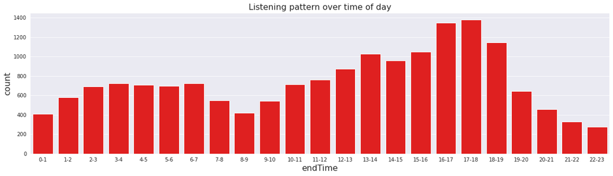

```python
plt.figure(figsize=(20, 5))
plt.title("Listening pattern over time of day", fontsize=16)
plt.xlabel("Time of Day", fontsize=16)
plt.ylabel("Number of Songs", fontsize=16)
sns.countplot(time_ranges, color='r');
```

#### 2. Number of songs played over day of week

Here I wanted to check how many songs I was listening to, on an average, through out the course of a week.

```
0    2510
1    2436
2    2694
3    1957
4    2192
5    2745
6    2822
Name: endTime, dtype: int64
```

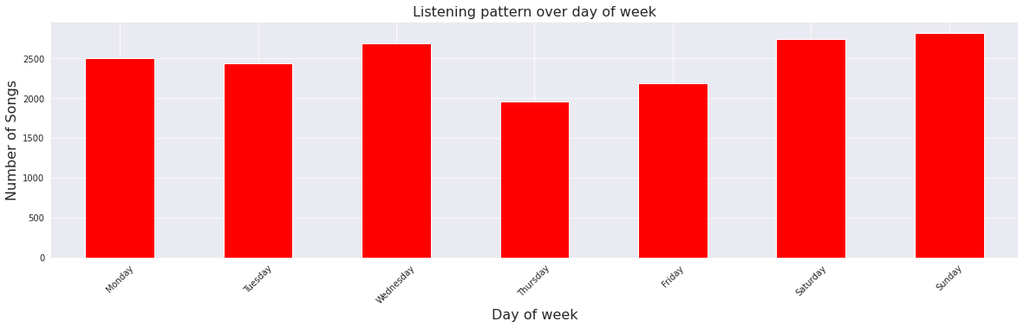

```python
day_names = ['Monday', 'Tuesday', 'Wednesday', 'Thursday', 'Friday', 'Saturday', 'Sunday']
plt.figure(figsize=(20, 5))
plt.title("Listening pattern over day of week", fontsize=16)
plt.xlabel("Day of week", fontsize=16)
plt.ylabel("Number of Songs", fontsize=16)
day_ranges = spotify_data_songs.endTime.dt.dayofweek.value_counts().sort_index()
ax = day_ranges.plot(kind="bar", color='r')
ax.set_xticks([0, 1, 2, 3, 4, 5, 6])
ax.set_xticklabels(day_names);
plt.xticks(rotation=45);
print(spotify_data_songs.endTime.dt.dayofweek.value_counts().sort_index())
```

#### We can see that Thursday had the least number of plays and it progressively increased from Friday to Sunday. Wednesdays also observed a large number of songs being played/streamed.

#### 3. Now I wanted to check the relation between the streaming patterns over days of week and hours of day.

This required a *groupby* operation on the dataframe.

```python
day_hr_count = spotify_data_songs.groupby(
    [spotify_data_songs.endTime.dt.dayofweek, spotify_data_songs.endTime.dt.hour]
).count()['trackName']
day_hr_count.index.set_names(["day", "hour"], inplace=True)
```

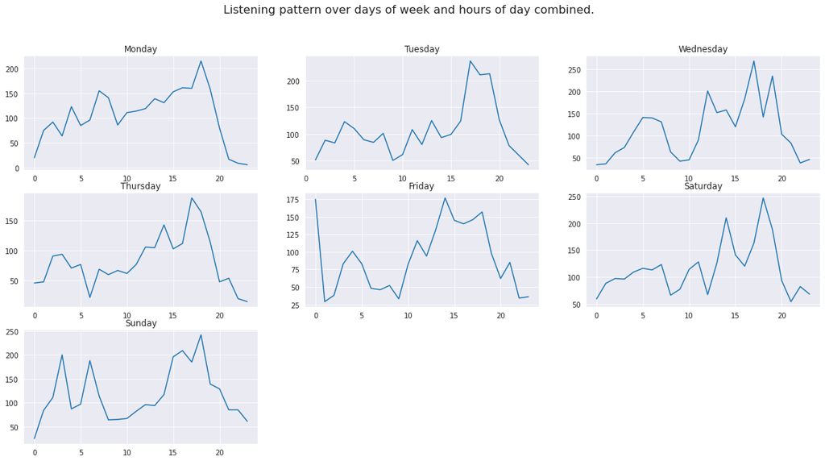

```python
fig, ax = plt.subplots(figsize=[20, 10])
lines = []
rows = 3
cols = 3
sub = 1
fig.suptitle("Listening pattern over days of week and hours of day combined.", fontsize=16)
day_numbers = list(range(7))
for day in day_numbers:
    plt.subplot(rows, cols, sub)
    ax = sns.lineplot(data=day_hr_count.loc[day])
    ax.set_xlabel('')
    ax.set_title(day_names[day])
    sub = sub + 1
```

#### 4. Some insights about the highest played tracks.

```python
song_play_counts = spotify_data_songs.groupby(
    ['artistName', 'trackName']
).count().sort_values('endTime', ascending=False).reset_index().rename(
    columns={'endTime': 'plays'}
).drop(columns='msPlayed')
song_play_counts.index += 1
song_play_counts[:10]
```

|  | artistName | trackName | plays |
| --- | --- | --- | --- |
| 1 | Frank Ocean | Pyramids | 60 |
| 2 | Lifafa | Jaago | 37 |
| 3 | Kailash Kher | Allah Ke Bande | 34 |
| 4 | Sathyaprakash | O Kalala Kathala | 33 |
| 5 | Lifafa | Nikamma | 29 |
| 6 | Lifafa | Din Raat | 26 |
| 7 | The Yellow Diary | Dheere Se | 26 |
| 8 | Agnee | Shaam Tanha | 24 |
| 9 | The Yellow Diary | Tere Jeya Hor Disda | 22 |
| 10 | Lifafa | Ek Nagma | 21 |

1. Pyramids by Frank Ocean, is the highest played track with 60 plays.
2. Of the top 10 songs played:
   1. Four of the songs are from the same album "Jaago" by the artist "Lifafa".
   2. Two of the songs are from another artist "The Yellow Diary".
3. Except for Frank Ocean's Pyramids, all the other top played songs are Hindi songs.

```python
updated_song_data = pd.read_csv("updated_song_data.csv")
updated_song_data.endTime = pd.to_datetime(updated_song_data.endTime, format="%Y-%m-%d %H:%M:%S" )
```

```python
top_10_tracks = list(song_play_counts[:10].trackName)
updated_song_data.query("trackName in @top_10_tracks").drop(columns=["msPlayed", "duration_ms", "time_signature", "mode", "liveness"])
```

|  | endTime | artistName | trackName | URI | danceability | energy | key | loudness | speechiness | acousticness | instrumentalness | valence | tempo | album | lyrics |
| --- | --- | --- | --- | --- | --- | --- | --- | --- | --- | --- | --- | --- | --- | --- | --- |
| 7347 | 2020-06-27 16:34:00 | Agnee | Shaam Tanha | spotify:track:5V6XcXBrCGI6JOeYr4Uyo3 | 0.404 | 0.193 | 11.0 | -12.501 | 0.0305 | 0.7940 | 0.000296 | 0.2730 | 77.026 | Agnee | Shaam Tanha Si Lage Hmmmm..... Sabhi Se Hum Be... |
| 7603 | 2020-07-07 18:54:00 | The Yellow Diary | Dheere Se | spotify:track:3gJxSEQtZ08xpRuAMdynHW | 0.892 | 0.548 | 6.0 | -8.449 | 0.3300 | 0.1390 | 0.000000 | 0.2620 | 112.962 | NaN | NaN |
| 7624 | 2020-07-07 20:24:00 | Kailash Kher | Allah Ke Bande | spotify:track:6Y1cH3RzDCMWGQtOS0HmP8 | 0.415 | 0.132 | 7.0 | -18.839 | 0.0353 | 0.9400 | 0.137000 | 0.1220 | 169.006 | Teri Dewani | Tuta tuta ek parinda aise tuta ke phir judna p... |
| 8442 | 2020-05-10 11:32:00 | The Yellow Diary | Tere Jeya Hor Disda | spotify:track:7nIyZpAsOH3U0dYBiozXea | 0.561 | 0.526 | 6.0 | -10.005 | 0.0258 | 0.7740 | 0.006050 | 0.4630 | 89.996 | NaN | NaN |
| 8827 | 2020-06-08 08:12:00 | Frank Ocean | Pyramids | spotify:track:4QhWbupniDd44EDtnh2bFJ | 0.400 | 0.650 | 5.0 | -6.104 | 0.0466 | 0.0118 | 0.000076 | 0.1500 | 107.989 | channel ORANGE | [Part I] [Hook] Set the cheetahs on the loose... |
| 9489 | 2020-07-09 11:15:00 | Lifafa | Nikamma | spotify:track:0bO9mhJpH5R5ixn9Gv8F6O | 0.715 | 0.676 | 6.0 | -11.895 | 0.2160 | 0.4830 | 0.001850 | 0.4680 | 181.859 | NaN | NaN |
| 9491 | 2020-07-09 11:24:00 | Lifafa | Din Raat | spotify:track:2PvYiLbxSTMuMnbS95g2NY | 0.578 | 0.734 | 7.0 | -10.928 | 0.0391 | 0.0231 | 0.384000 | 0.0729 | 123.010 | Jaago | Jaadu Tera yeh jalwa Pee loon Jab kaabu mein a... |
| 9492 | 2020-07-09 11:28:00 | Lifafa | Ek Nagma | spotify:track:5jU1g2XwItLlREmuecfO0Y | 0.644 | 0.696 | 10.0 | -11.327 | 0.0431 | 0.1330 | 0.619000 | 0.2020 | 123.012 | Jaago | Meri aankhein Jhooti nahi In meh baatein Meeth... |
| 9493 | 2020-07-09 11:32:00 | Lifafa | Jaago | spotify:track:0zyhmMx0b3CFDfyOuh2ZmC | 0.438 | 0.303 | 5.0 | -13.122 | 0.0692 | 0.5550 | 0.094600 | 0.0394 | 129.964 | NaN | NaN |
| 9606 | 2020-07-13 23:03:00 | Sathyaprakash | O Kalala Kathala | spotify:track:1akk6cJYNDlZUgpLoXvYMz | 0.693 | 0.623 | 9.0 | -7.555 | 0.0454 | 0.1660 | 0.000000 | 0.3890 | 91.977 | NaN | NaN |

#### Average tempo of the top 10 songs is not so high, also, the low values of danceability, energy and valence indicate that the songs are not high beat songs and are rather relaxing to listen to.

#### Also, it's a good variety of songs, some have high danceability and some have very low. This means that, I enjoy calm music rather than fast beat ones.

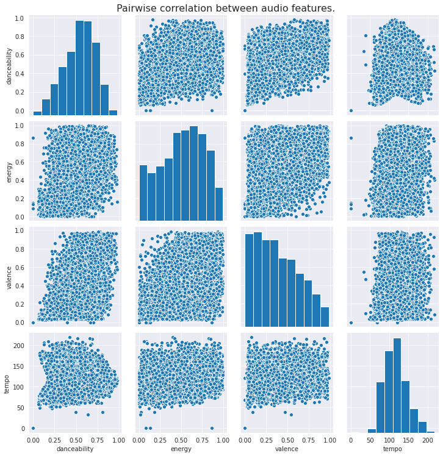

```python
ax = sns.pairplot(updated_song_data.drop(
    columns=["msPlayed", "duration_ms", "key", "instrumentalness", "speechiness", "loudness", "acousticness", "time_signature", "mode", "liveness"]
));
ax.fig.suptitle('Pairwise correlation between audio features.', fontsize=16,  y=1.02);
```

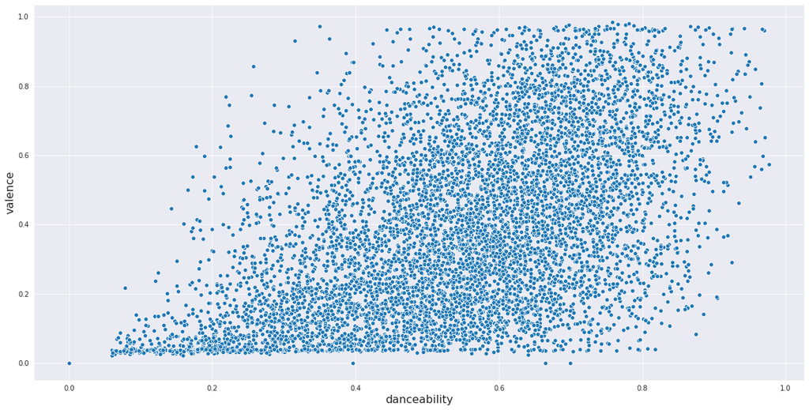

```python
plt.figure(figsize=(20, 10))
plt.xlabel("Danceability", fontsize=16)
plt.ylabel("Valence", fontsize=16)
sns.scatterplot(data=updated_song_data, x="danceability", y="valence");
```

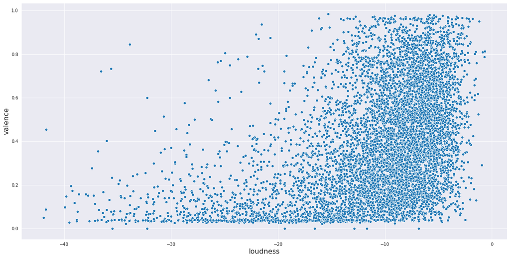

```python
plt.figure(figsize=(20, 10))
plt.xlabel("Danceability", fontsize=16)
plt.ylabel("Valence", fontsize=16)
sns.scatterplot(data=updated_song_data, x="loudness", y="valence");
```

```
1. Darker color ( Blue ) indicates high positive correlation
2. Lighter color ( cream/ white ) indicates high negative correlation.
```

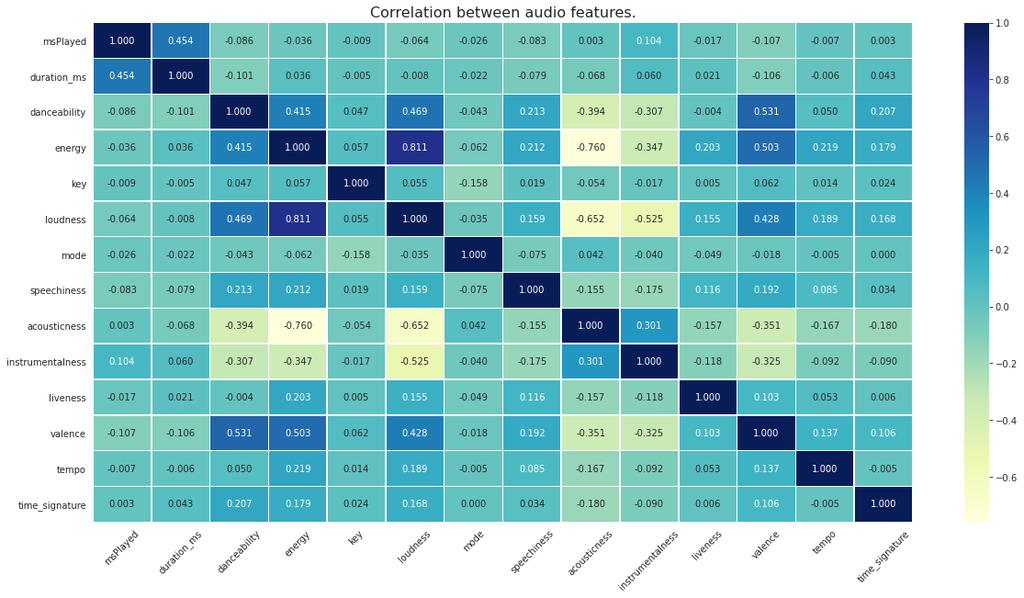

```python
fig, ax = plt.subplots(figsize=(20, 10))
corr = updated_song_data.corr()
sns.heatmap(
    corr,
    xticklabels=corr.columns.values,
    yticklabels=corr.columns.values,
    annot=True,
    fmt=".3f",
    linewidths=.5,
    cmap="YlGnBu"
);
plt.xticks(rotation=45);
plt.title('Correlation between audio features.', fontsize=16);
print("""
1. Darker color ( Blue ) indicates high positive correlation
2. Lighter color ( cream/ white ) indicates high negative correlation.
""")
```

1. High positive correlation between:
   1. Energy and Loudness 81%
   2. Valence and Energy, Danceability, loudness 50%, 53%, 42%.
2. High negative correlation between:
   1. Acousticness and Energy Looudness -75%, -65%

#### All the above scatter plots and heatmaps helped us identify that there are only 6 important features that represent the song and hence only they will be used to make any analysis.

1. Danceability
2. Energy
3. Loudness
4. Acousticness
5. Instrumentalness
6. Valence

#### 5. Highest played artists.

```python
artist_play_counts = spotify_data_songs.groupby(['artistName']).count().sort_values(
    'endTime', ascending=False
).reset_index().rename(
    columns={'endTime': 'plays'}
).drop(columns=['msPlayed', 'trackName'])
artist_play_counts.index += 1
artist_play_counts[:10]
```

|  | artistName | plays |
| --- | --- | --- |
| 1 | Lifafa | 194 |
| 2 | Frank Ocean | 166 |
| 3 | Kailash Kher | 137 |
| 4 | Gorillaz | 136 |
| 5 | Amit Trivedi | 135 |
| 6 | A.R. Rahman | 123 |
| 7 | Pink Floyd | 101 |
| 8 | The Weeknd | 100 |
| 9 | King Crimson | 90 |
| 10 | David Gilmour | 85 |

#### 1. It's no surprise that "Lifafa" is the highest played artist in my Spotify streaming history. Closely followed by Frank Ocean.

#### 2. Four of the top 10 artists are Indian and their songs are of the Hindi language.

```python
top_10_artists = list(artist_play_counts[:10].artistName)
updated_song_data.query("artistName in @top_10_artists").describe()
```

|  | msPlayed | duration_ms | danceability | energy | key | loudness | mode | speechiness | acousticness | instrumentalness | liveness | valence | tempo | time_signature |
| --- | --- | --- | --- | --- | --- | --- | --- | --- | --- | --- | --- | --- | --- | --- |
| count | 3.630000e+02 | 3.630000e+02 | 363.000000 | 363.000000 | 363.000000 | 363.000000 | 363.000000 | 363.000000 | 363.000000 | 363.000000 | 363.000000 | 363.000000 | 363.000000 | 363.000000 |
| mean | 1.968357e+05 | 2.870066e+05 | 0.519553 | 0.511059 | 5.090909 | -11.041884 | 0.595041 | 0.065528 | 0.352830 | 0.198313 | 0.240183 | 0.394971 | 119.628983 | 3.837466 |
| std | 1.682696e+05 | 1.292797e+05 | 0.186470 | 0.231328 | 3.550737 | 5.372304 | 0.491562 | 0.063522 | 0.323014 | 0.327352 | 0.237954 | 0.259893 | 29.472494 | 0.485737 |
| min | 0.000000e+00 | 4.564000e+04 | 0.071600 | 0.001870 | 0.000000 | -38.659000 | 0.000000 | 0.024000 | 0.000040 | 0.000000 | 0.036000 | 0.029500 | 51.751000 | 1.000000 |
| 25% | 2.873550e+04 | 2.117005e+05 | 0.374000 | 0.338500 | 2.000000 | -13.462000 | 0.000000 | 0.033500 | 0.045600 | 0.000024 | 0.097450 | 0.167000 | 94.671000 | 4.000000 |
| 50% | 2.064290e+05 | 2.635730e+05 | 0.511000 | 0.511000 | 5.000000 | -10.022000 | 1.000000 | 0.042500 | 0.265000 | 0.001800 | 0.128000 | 0.338000 | 120.017000 | 4.000000 |
| 75% | 2.797930e+05 | 3.379195e+05 | 0.672500 | 0.700500 | 8.000000 | -7.265500 | 1.000000 | 0.061850 | 0.611500 | 0.305000 | 0.273000 | 0.584000 | 138.054500 | 4.000000 |
| max | 1.410830e+06 | 1.412451e+06 | 0.968000 | 0.985000 | 11.000000 | -2.392000 | 1.000000 | 0.472000 | 0.994000 | 0.972000 | 0.984000 | 0.968000 | 206.473000 | 5.000000 |

#### Analogous to the features of the top 10 songs, all the songs I have streamed of the top 10 artists are also having a low tempo, moderate danceability, energy and valence, so, chill music.

#### 6. Songs streamed month wise.

```python
spotify_data_songs['season'] = pd.cut(
    (spotify_data_songs.endTime.dt.dayofyear + 11) % 366,
    [0, 91, 183, 275, 366],
    labels=['Winter', 'Spring', 'Summer', 'Fall']
)
```

```python
month_play_count = spotify_data_songs.groupby(spotify_data_songs.endTime.dt.month).count().drop(
    columns=["endTime", 'artistName', "trackName"]
).reset_index().sort_values(
    "msPlayed", ascending=False
).rename(columns={"endTime": "month", "msPlayed": "plays"})
month_play_count
```

|  | month | plays | season |
| --- | --- | --- | --- |
| 1 | 2 | 2235 | 2235 |
| 8 | 9 | 1983 | 1983 |
| 0 | 1 | 1970 | 1970 |
| 7 | 8 | 1567 | 1567 |
| 5 | 6 | 1564 | 1564 |
| 11 | 12 | 1507 | 1415 |
| 9 | 10 | 1493 | 1493 |
| 6 | 7 | 1485 | 1485 |
| 4 | 5 | 1055 | 1055 |
| 10 | 11 | 1025 | 1025 |
| 2 | 3 | 775 | 775 |
| 3 | 4 | 697 | 697 |

#### Add the categorical variable "season" to divide the months of a year into seasons.

```
Winter    5605
Summer    5172
Fall      3619
Spring    2868
Name: season, dtype: int64
```

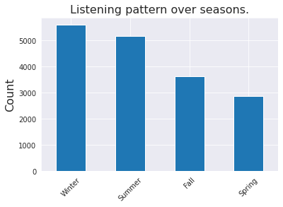

```python
print(spotify_data_songs.season.value_counts())
ax = spotify_data_songs.season.value_counts().plot(kind="bar");
plt.title("Listening pattern over seasons.", fontsize=16)
plt.ylabel("Count", fontsize=16)
plt.xticks(rotation=45);
```

1. March and April had the lowest number of songs streamed ( 775 and 697 respectively ).
2. January, February and September have the highest number of plays.
3. Winter season observed the highest number of songs played. #### Since winter season has the highest number of plays, we can explore the type of songs played in these months.

```python
updated_song_data['season'] = pd.cut(
    (updated_song_data.endTime.dt.dayofyear + 11) % 366,
    [0, 91, 183, 275, 366],
    labels=['Winter', 'Spring', 'Summer', 'Fall']
)
```

```python
from wordcloud import WordCloud, STOPWORDS
stopwords = set(STOPWORDS)
```

```python
def get_wordcloud(month_df):
    month_df = pd.DataFrame(month_df.lyrics.dropna())
    month_df.lyrics = month_df.lyrics.str.replace(r'\[.*\]|\(.*\)', '')
    all_words = ""
    for song in month_df.lyrics:
        tokens = song.split()
        for i in range(len(tokens)):
            tokens[i] = tokens[i].lower()
        for words in tokens:
            all_words += words + ' '
    wordcloud = WordCloud(width = 800, height = 800,
                background_color ='white',
                stopwords = stopwords,
                min_font_size = 10).generate(all_words)
    plt.figure(figsize = (8, 8), facecolor = None)
    plt.imshow(wordcloud)
    plt.axis("off")
    plt.tight_layout(pad = 0)
    plt.show()
```

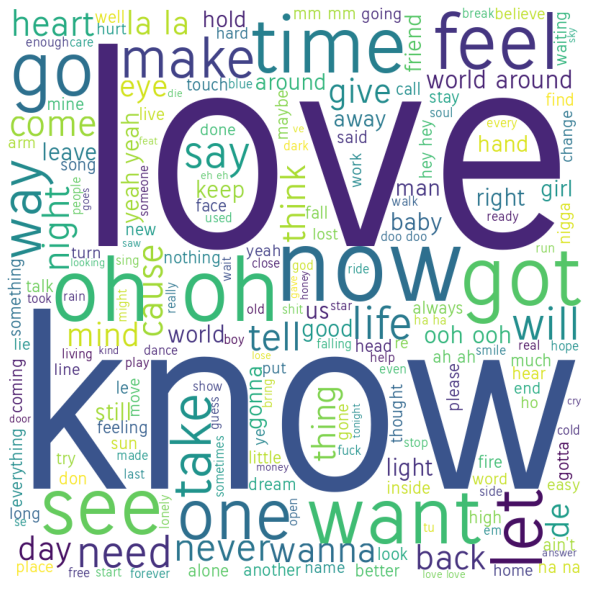

```python
get_wordcloud(updated_song_data.query("season == 'Winter'"))
```

#### The theme of the winter season is - Love.

#### We'll understand the tempo of the songs played with respect to the seasons.

```python
mean_song_features = updated_song_data.groupby([updated_song_data.season]).mean()
mean_song_features.drop(columns=["msPlayed", "duration_ms", "mode", "liveness", "key", "loudness", "speechiness", "time_signature"], inplace=True)
mean_song_features.tempo /= 1000
mean_song_features
```

| season | danceability | energy | acousticness | instrumentalness | valence | tempo |
| --- | --- | --- | --- | --- | --- | --- |
| Winter | 0.549295 | 0.526835 | 0.401941 | 0.252352 | 0.412855 | 0.114878 |
| Spring | 0.532733 | 0.495603 | 0.436252 | 0.297804 | 0.371337 | 0.116941 |
| Summer | 0.526959 | 0.497419 | 0.426566 | 0.314531 | 0.368897 | 0.116056 |
| Fall | 0.552427 | 0.536380 | 0.372124 | 0.289428 | 0.385198 | 0.118995 |

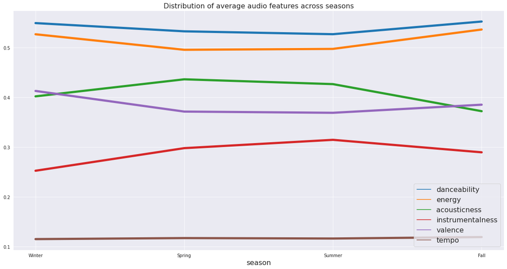

```python
plt.figure(figsize=[20, 10])
ax = sns.lineplot(data=mean_song_features, dashes=False, linewidth=5);
plt.title('Distribution of average audio features across seasons', fontsize=16);
plt.xlabel("season", fontsize=16)
plt.legend(loc="lower right", markerscale=22, fontsize=16);
```

1. Analogous to our previous observations, the tempo remains constant throughout the year.
2. Spring and Summer have more of acoustic and instrumental songs being played.
3. In Fall, higher energy songs are played, which have valence and danceability

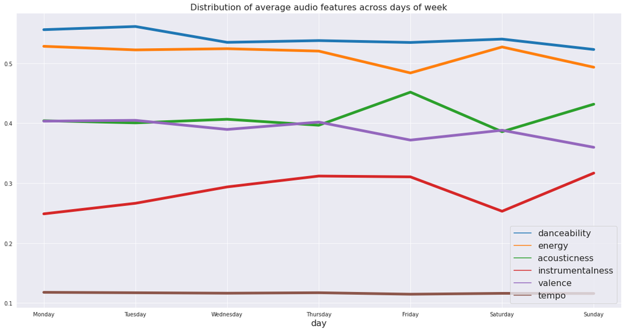

```python
mean_song_features_week = updated_song_data.groupby([updated_song_data.endTime.dt.dayofweek]).mean()
mean_song_features_week.drop(columns=["msPlayed", "duration_ms", "mode", "liveness", "loudness", "key", "speechiness", "time_signature"], inplace=True)
mean_song_features_week.tempo /= 1000
plt.figure(figsize=[20, 10])
ax = sns.lineplot(data=mean_song_features_week, dashes=False, linewidth=5);
plt.title('Distribution of average audio features across days of week', fontsize=16);
plt.xlabel("day", fontsize=16)
plt.legend(loc="lower right", markerscale=22, fontsize=16);
ax.set_xticks([0, 1, 2, 3, 4, 5, 6])
ax.set_xticklabels(day_names);
```

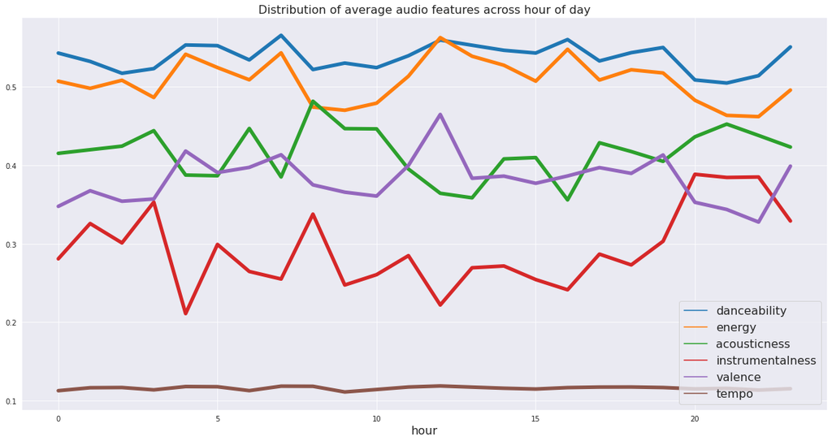

```python
mean_song_features_week = updated_song_data.groupby([updated_song_data.endTime.dt.hour]).mean()
mean_song_features_week.drop(columns=["msPlayed", "duration_ms", "mode", "liveness", "loudness", "key", "speechiness", "time_signature"], inplace=True)
mean_song_features_week.tempo /= 1000
plt.figure(figsize=[20, 10])
ax = sns.lineplot(data=mean_song_features_week, dashes=False, linewidth=5);
plt.title('Distribution of average audio features across hour of day', fontsize=16);
plt.xlabel("hour", fontsize=16)
plt.legend(loc="lower right", markerscale=22, fontsize=16);
```

```python
# Total number of milliseconds, I have listened to music for, over the course of a year.
spotify_data_songs.msPlayed.sum()
```

```
3550291840
```

```python
len(updated_song_data)
```

```
9610
```

#### 3550291840ms = 986.2 hours = 41.09 days = 5.87 weeks = 1.35 months

#### Findings

1. Correlation between the valence, danceability and energy. About how the average tempo and the feature of songs are neutral/moderate in nature. Pointing towards relaxing music
2. Frequency of streams on weekdays and hours of day, points towards of levels of productivity throughout the day or week.